# Harvest_RMD

Zjrobbin

9/9/2020

The harvest module was parameterized using hte EVALIDATOR data tool. Evalidator use sql to query the most recent FIA census for an area. I broke down the data by county, and used a map of the counties within our study area to associate the data.

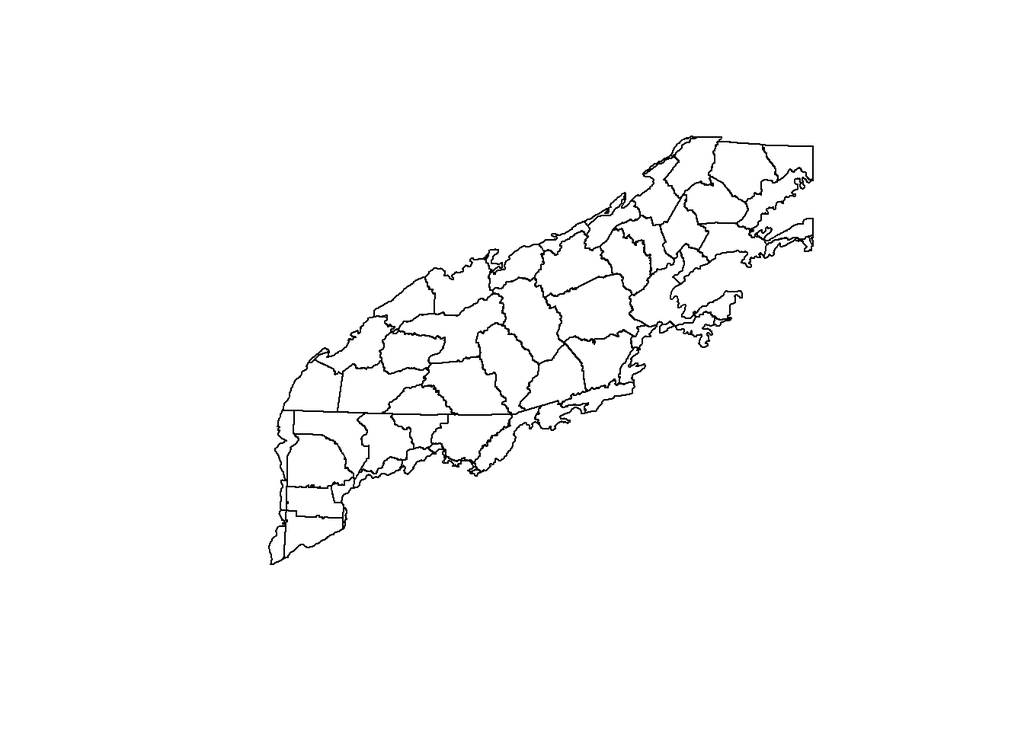

```r
library(reshape2)
library(ggplot2)
library(rgdal)
w_dir<-"Z:/Robbins/Sapps/Model_Prep/Harvest_Work/"
setwd(w_dir)
Countyshape<-readOGR(paste(w_dir,'Clip_county_correct.shp',sep=""))
plot(Countyshape)
```

```r
Countyshapedf<-as.data.frame(Countyshape)
Countys_in<-paste(Countyshapedf$STATEFP,Countyshapedf$COUNTYFP,sep="")
```

```r
#Plots

TL_AgeClass_DF<-read.csv(paste(w_dir,"TL_Age_Class_DF.csv",sep=""))
TL_Ownership_DF<-read.csv(paste(w_dir,"TL_Ownership_DF.csv",sep=""))

AgeClass_DF<-read.csv(paste(w_dir,'Age_Class_DF.csv',sep=""))
Ownership_DF<-read.csv(paste(w_dir,"Ownership_DF.csv",sep=""))

TL_AgeClass_DF$Landtype<-"Timberlands"
AgeClass_DF$Landtype<-"Forestlands"
TL_Ownership_DF$Landtype<-"Timberlands"
Ownership_DF$Landtype<-"Forestlands"


colnames(AgeClass_DF)
```

```
##  [1] "X"            "Total"        "WRJP"         "SpFir"        "LngSl"
##  [6] "LobSh"        "OthESw"       "OkP"          "OkH"          "OkGC"
## [11] "EAC"          "MapBB"        "AsBir"        "OtHw"         "TropHw"
## [16] "ExHd"         "Nons"         "STCountycode" "Age_Class"    "Landtype"
```

```r
colnames(TL_AgeClass_DF)
```

```
##  [1] "X"         "Total"     "WRJP"      "SpFir"     "LngSl"     "LobSh"
##  [7] "OthESw"    "OkP"       "OkH"       "OkGC"      "EAC"       "MapBB"
## [13] "OtHw"      "TropHw"    "ExHd"      "Nons"      "NA."       "NA..1"
## [19] "Age_Class" "Landtype"
```

```r
AgeClass_DF<-AgeClass_DF[,c(-18)]
TL_AgeClass_DF<-TL_AgeClass_DF[,c(-17,-18)]
TL_AgeClass_DF$AsBir<-NA
AllAgeClass<-rbind(TL_AgeClass_DF)

AllAgeClass[,c(2:16)]<-AllAgeClass[,c(2:16)]*224.17 ##(covert short tons per acre to g/m2)

theme_set(theme_gray(base_size = 18))
AA_melt<-melt(AllAgeClass, id.vars = c("Age_Class","Landtype"), measure.vars = c(colnames(AllAgeClass[,c(2:16)])))
AA_melt_sub<-AA_melt[AA_melt$Age_Class!='Sum',]
colnames(AllAgeClass)
```

```
##  [1] "X"         "Total"     "WRJP"      "SpFir"     "LngSl"     "LobSh"
##  [7] "OthESw"    "OkP"       "OkH"       "OkGC"      "EAC"       "MapBB"
## [13] "OtHw"      "TropHw"    "ExHd"      "Nons"      "Age_Class" "Landtype"
## [19] "AsBir"
```

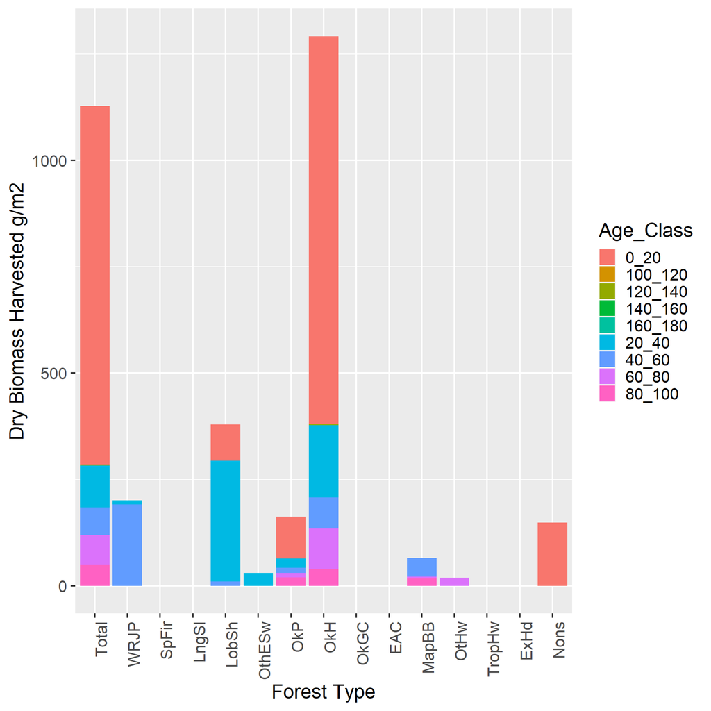

```r
ggplot(AA_melt_sub, aes(fill=Age_Class, y=value, x=variable)) +
  geom_bar(stat="identity")+
  ylab("Dry Biomass Harvested g/m2")+
  xlab("Forest Type")+
  theme(text = element_text(size=20),
        axis.text.x = element_text(angle=90, hjust=1))
```

WRJP= Jack Pine, Red pine ,easter white pine, eastern white pine hemlock, hemlock SpFir= Balsam, White spruce, red spruce, redspiurce/basam, black spruce, tamarack northern white ceder. #Longleaf/Slash pine= #Lobllogy/Shortleaf pine= #Other eastern soft= Eastern redcedar. #OakPine: Pine component needs to be 25-49 percent. #Oak Hickory: #Oak Gum Cypress: #Elm/ash/Cottonwood #MapleBeech Birch ###Aspen Birch-pin cherry and paper birch. #other hardwoods

So looking at this it seems like most of the harvest is in the white pine/red pine, Loblolly/Shortleaf pine, Oak Pine/Oak Hicokory, and Some Maple.

StandRanking Economic

| Species | Economic Rank | MinimumAge |
| --- | --- | --- |
| PinuStro | 80 | 40 |
| PinuTaed | 80 | 20 |
| PinuEnch | 60 | 20 |
| QuerAlba | 30 | 20 |
| QuerCocc | 30 | 20 |
| QuerFalc | 30 | 20 |
| QuerRubr | 30 | 20 |
| QuerStel | 30 | 20 |
| QuerVelu | 30 | 20 |
| AcerSacc | 30 | 40 |
| CaryAlba | 20 | 40 |
| CaryOvat | 20 | 40 |
| CaryCodi | 20 | 40 |
| CaryGlab | 20 | 40 |
| JuglNigr | 10 | 30 |

```r
colnames(TL_Ownership_DF)
```

```
##  [1] "X"         "Total"     "WRJP"      "SpFir"     "LngSl"     "LobSh"
##  [7] "OthESw"    "OkP"       "OkH"       "OkGC"      "EAC"       "MapBB"
## [13] "OtHw"      "TropHw"    "ExHd"      "Nons"      "NA."       "NA..1"
## [19] "Ownership" "Landtype"
```

```r
colnames(Ownership_DF)
```

```
##  [1] "X"            "Total"        "WRJP"         "SpFir"        "LngSl"
##  [6] "LobSh"        "OthESw"       "OkP"          "OkH"          "OkGC"
## [11] "EAC"          "MapBB"        "AsBir"        "OtHw"         "TropHw"
## [16] "ExHd"         "Nons"         "STCountycode" "Ownership"    "Landtype"
```

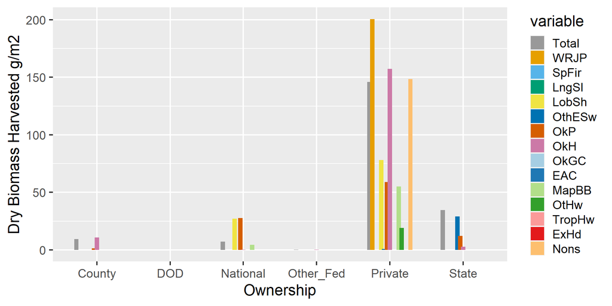

```r
TL_Ownership_DF<-TL_Ownership_DF[,c(-17,-18)]
Ownership_DF<-Ownership_DF[,c(-18)]
TL_Ownership_DF$AsBir<-NA
AllOwnership<-rbind(TL_Ownership_DF)
AllOwnership[,c(2:16)]<-AllOwnership[,c(2:16)]*224.17 ##(covert short tons per acre to g/m2)
library(reshape2)
library(ggplot2)
library(RColorBrewer)
Own_melt<-melt(AllOwnership, id.vars = c("Ownership","Landtype"), measure.vars = c(colnames(AllAgeClass[,c(2:16)])))
Own_melt_sub<-Own_melt[Own_melt$Ownership!='Total',]
cbPalette <- c("#999999", "#E69F00", "#56B4E9", "#009E73", "#F0E442", "#0072B2", "#D55E00", "#CC79A7")

ggplot(Own_melt_sub, aes(fill=variable, y=value, x=Ownership)) +
  geom_bar(aes(fill = variable), position = position_dodge(0.6),stat="identity")+
  ylab("Dry Biomass Harvested g/m2")+
  xlab("Ownership")+
  scale_fill_manual(values=c(cbPalette,brewer.pal(7,'Paired')))
```

Here are the totals by ownership.

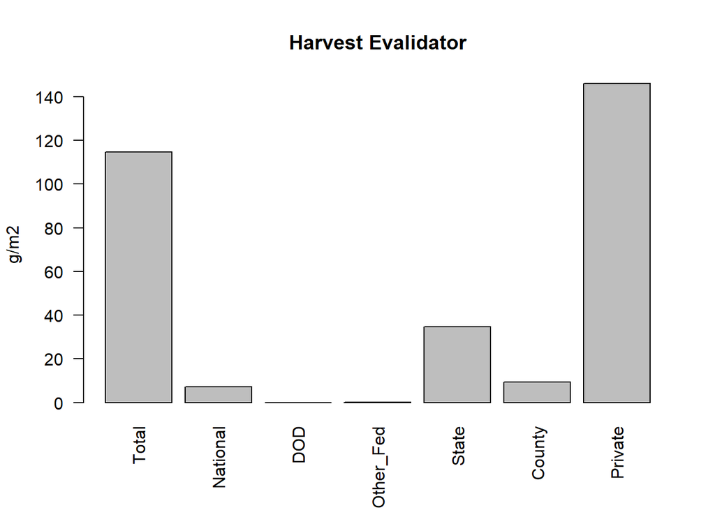

```r
barplot(AllOwnership$Total,names=AllOwnership$Ownership,las=2,ylab="g/m2",
        main="Harvest Evalidator")
```

This was used to validate the amount of commercial harvest on the landscape.

#### Making the Map

##### [Landownership](https://www.fs.usda.gov/rds/archive/Product/RDS-2017-0007)

From the FS Website

This data publication contains 250 meter raster data depicting the spatial distribution of forest ownership types in the conterminous United States. The data are a modeled representation of forest land by ownership type, and include three types of public ownership: federal, state, and local; three types of private: family (includes individuals and families), corporate, and other private (includes conservation and natural resource organizations, and unincorporated partnerships and associations); as well as Native American tribal lands. The most up-to-date data available were used in creating this data publication.

A plurality of the ownership data were from 2014, but some data were as old as 2004.

```python
####Import libraries
import rasterio as rt
import geopandas as gp
import gdal
from rasterio.mask import mask
###Get coordinate features and geometry
def getFeatures(gdf):
    """Function to parse features from GeoDataFrame in such a manner that rasterio wants them"""
    import json
    return [json.loads(gdf.to_json())['features'][0]['geometry']]

##Work Drive
w_dir="E:/Harvest_Work/"
###The orgininal Ownership raster
Ownership=(w_dir+"/RDS-2017-0007/Data/forown2016/hdr.adf")

###Study Area
AOI=gp.read_file(w_dir+"Dissolved_AOI.shp")
##Get CRS
ShpCRS=AOI.crs
###Warp raster
### I entered CRS manually
input_raster = gdal.Open(Ownership)
output_raster=(w_dir+"Ownership_reproj.tif")
gdal.Warp(output_raster,input_raster,dstSRS='EPSG:26917')
###Bring back reshaped raster
reshape_Ownership=rt.open(w_dir+"Ownership_reproj.tif")
###Get geometry from Study Area
coords=getFeatures(AOI)

###Get meta from raster
out_meta = reshape_Ownership.meta.copy()
###Mask raster to study area
out_img,out_transform=mask(raster=reshape_Ownership,shapes=coords,crop=True)
out_meta = reshape_Ownership.meta.copy()
epsg_code = int(reshape_Ownership.crs.data['init'][5:])
###Update meta data for new mask raster
out_meta.update({"driver": "GTiff",
                 "height": out_img.shape[1],
                 "width": out_img.shape[2],
                 "transform": out_transform}
                    )
###Set drive for masked raster
out_tif=w_dir+"Oship_cut.tif"
###Write Raster
with rt.open(out_tif, "w", **out_meta) as dest:
    dest.write(out_img)
```

```r
library(raster)
library(rgdal)
library(raster)
library(sf)
```

```r
library(utils)
library(ggplot2)
library(RColorBrewer)
library(rgdal)
```

```r
Oshipcut<-raster::raster(paste(w_dir,'Oship_cut.tif',sep=""))
crs(Oshipcut)<-CRS("+init=EPSG:26917")
SampleEcoregion<-raster::raster(paste(w_dir,'Inputs/MR_FourEcoregions.tif',sep=""))
crs(SampleEcoregion)<-CRS("+init=EPSG:26917")
resampled<-resample(Oshipcut,SampleEcoregion,method='ngb')
filename<-paste(w_dir,"Ownership_Resampled.tif")
writeRaster(resampled, filename=filename, datatype='INT4S',overwrite=TRUE)#Th
```

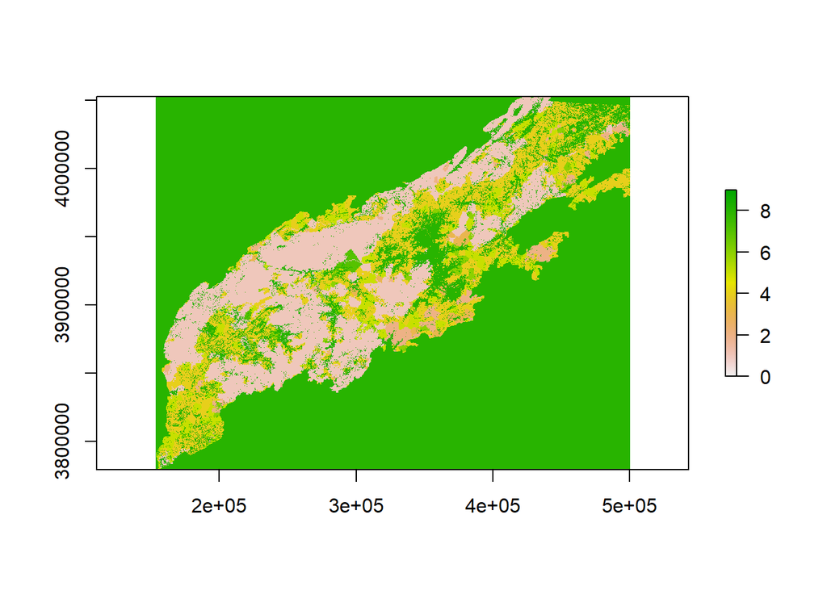

```r
Ownership<-raster(paste0(w_dir,'Ownership_Resampled.tif'))
plot(Ownership,zlim=c(0,9))
```

#>>1-Federal *# >>2-State #>>3-Local #>>4- Family* # >>5-Corporate* # >> 6- Other Private #>>7- Tribal #>>8- Off

To create the stand map I crossed the Ownership map with the HUC Watershed map, so that each owneship with a water shed is its own stand.

https://viewer.nationalmap.gov/basic/?basemap=b1&category=nhd&title=NHD%20View

```r
library(RColorBrewer)
Random<-brewer.pal(13,"Set3")
```

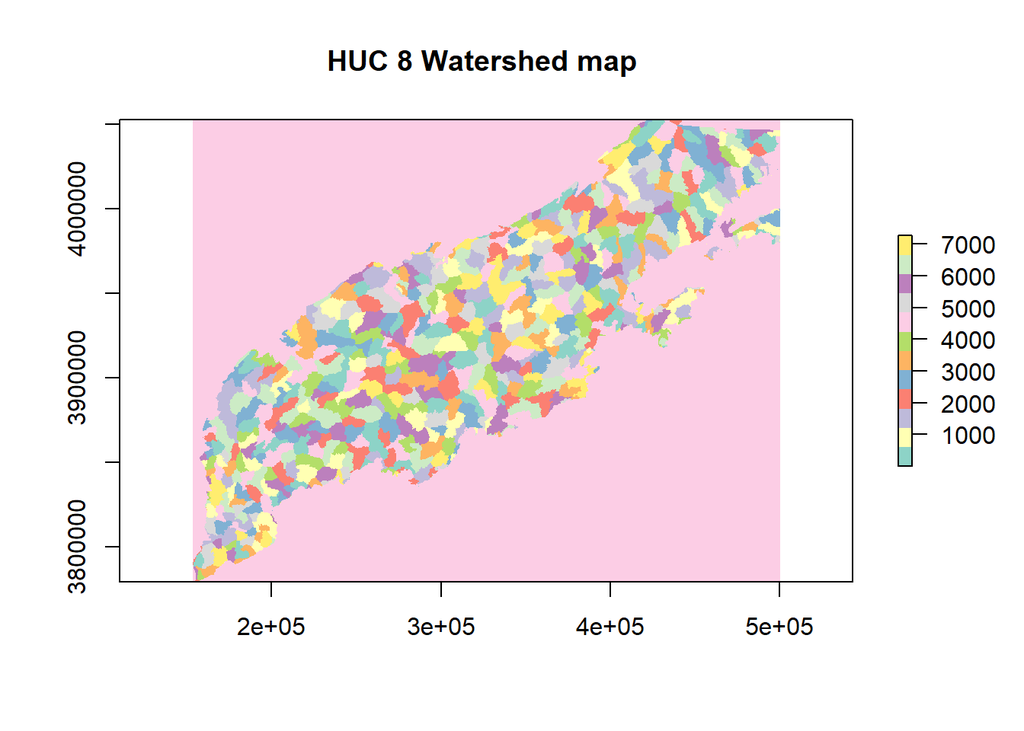

```r
plot(raster::raster(paste0(w_dir,"Watersheds.tif")),main="HUC 8 Watershed map ",col=rep(Random,10000) )
```

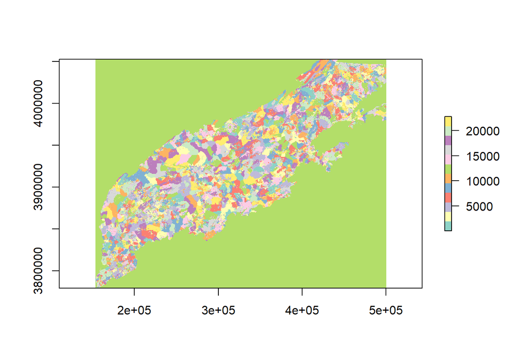

```r
Stands3<-raster::raster(paste0(w_dir,"Stands3.tif"))
plot(Stands3,col=rep(Random,10000))
```

```r
length(unique(Stands3))
```

```
## [1] 22813
```

That gives us 22,000 stands

```r
### Stand Size
StandSize<-sqrt((650000*62500)/22000)
### Gap size
sqrt(.20*(StandSize**2))
```

```
## [1] 607.7155
```

### Comparing to the Data.

So we ran the model using the parameters and here are the results

```r
LANDIS_summary<-read.csv(paste0(w_dir,"biomass-harvest-summary-log9_9_2.csv"))
#colnames(LANDIS_summary)
keep<-c(1:7,56:103)
LS_s<-LANDIS_summary[,keep]
```

```r
Ownership<-raster(paste0(w_dir,'Ownership_Resampled.tif'))
Ownershipcells<-as.data.frame(
    table(
      as.data.frame(
          Ownership)))

Ownershipcells$Area<-Ownershipcells$Freq*62500
colnames(Ownershipcells)<-c("ManagementArea","Cells","Area(m)")

Managements<-unique(LS_s$ManagementArea)
Prescriptions<-unique(LS_s$Prescription)
HL_DF<-NULL
for(Management in Managements){
  for(Prescription in Prescriptions){
    Harv<- LS_s[LS_s$Prescription==Prescription,]
    sus<-Harv[Harv$ManagementArea==Management,]

    MergedOneM<-merge(
      sus,
      Ownershipcells,
      by="ManagementArea",
      all.x=T
    )
    MO_Columns<-colnames(MergedOneM)
    Names<-MO_Columns[8:55]
    Names<-gsub("Mg","g_m2_",Names)
    GramMetersq<-(MergedOneM[8:55]*1000000)/MergedOneM$`Area(m)`

    GramMean<-t(as.data.frame(colMeans(GramMetersq)))
    colnames(GramMean)<-Names
    OutRow<-cbind(MergedOneM[1,1:3],GramMean)
    HL_DF<-rbind(OutRow,HL_DF)
  }
}
HL_DF$Total<-rowSums(HL_DF[4:51])
HL_DF<-HL_DF[complete.cases(HL_DF),]
```

```r
LUT<-data.frame(ManagementArea=c(1,2,3,4,5,6,7,8),
                Name=c("Federal","State","Local","Family",
                       "Corporate","Other_Private","Tribal","Off"))
HL_DF<-merge(HL_DF,
        LUT,
        by="ManagementArea",
        all.x=T)

ComThin<-HL_DF[HL_DF$Prescription==" CommercialThin",]
EcoHarvest<-HL_DF[HL_DF$Prescription==" EconomicHarvest",]
```

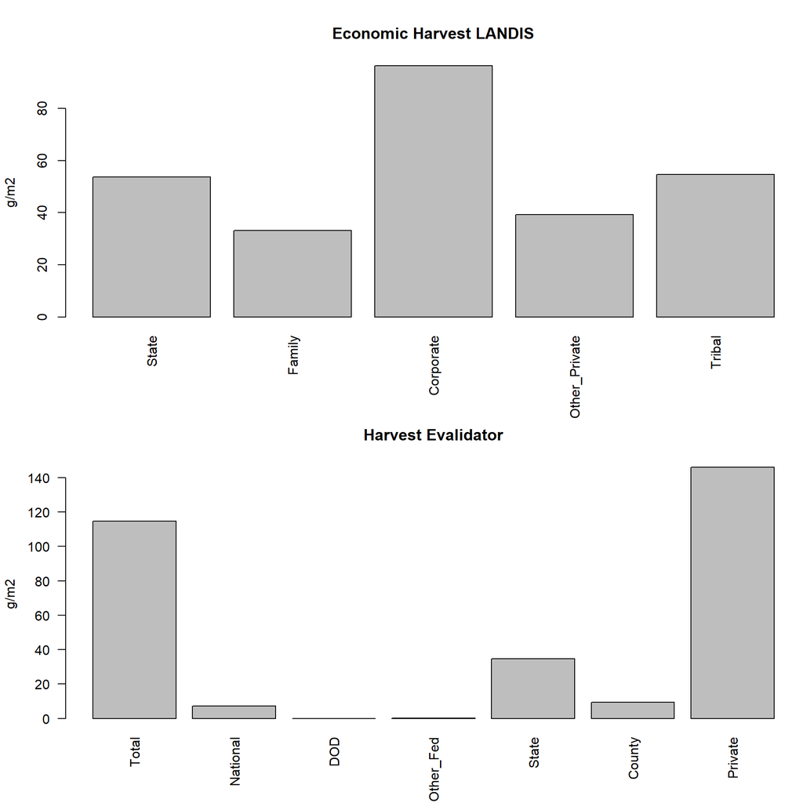

```r
par(mfrow=c(2,1),mar=c(5.1,4.1,4.1,.1))
barplot(EcoHarvest$Total,names=EcoHarvest$Name,las=3,ylab="g/m2",
        main="Economic Harvest LANDIS")
barplot(AllOwnership$Total,names=AllOwnership$Ownership,las=2,ylab="g/m2",
        main="Harvest Evalidator")
```

### Here is what is getting harvested.

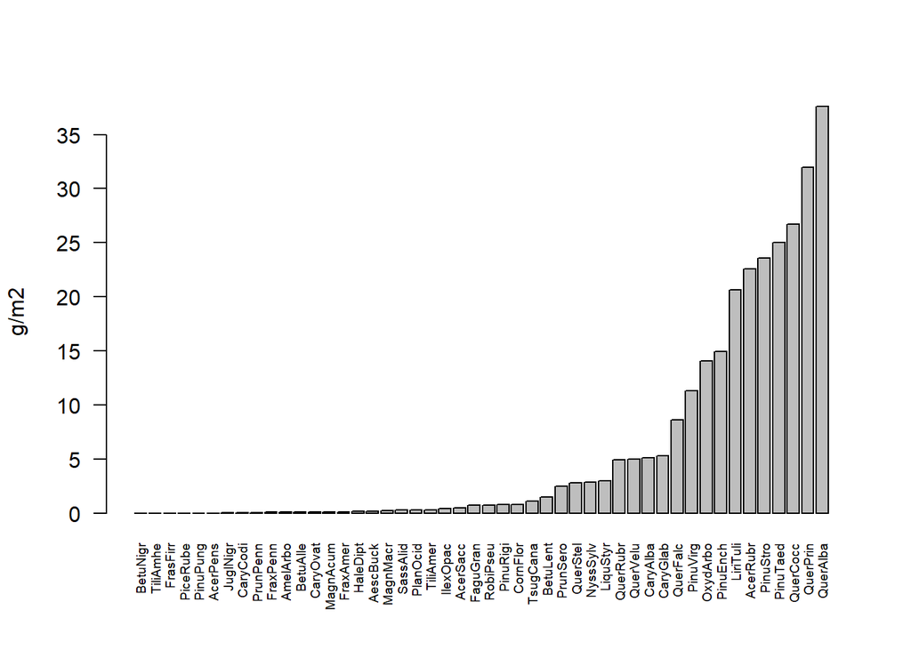

```r
EcoHarvestSums<-(as.data.frame(colSums(EcoHarvest[4:51])))
SP_Nm<-gsub("BiomassHarvestedg_m2__","",colnames(EcoHarvest[4:51]))
EcoHarvestSums$Name<-SP_Nm
colnames(EcoHarvestSums)<-c("Mean","Name")
EcoHarvestSums<-EcoHarvestSums[order(EcoHarvestSums$Mean),]
barplot(EcoHarvestSums$Mean,names=EcoHarvestSums$Name, ylab=c("g/m2"),
        las=2,cex.names=.6)
```

Here is the small amount of commerical thinning going on

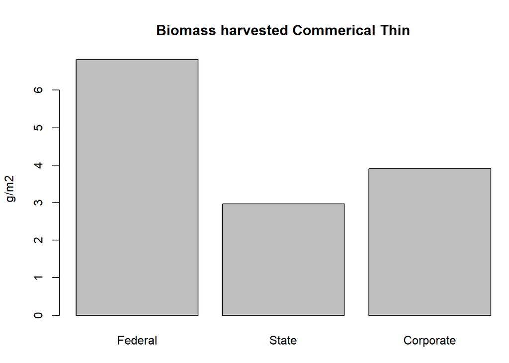

```r
par(mfrow=c(1,1),mar=c(3.1,4.1,4.1,.1))
barplot(ComThin$Total,names=ComThin$Name,ylab="g/m2",main="Biomass harvested Commerical Thin")
```

# Here is what is getting harvested for thinning.

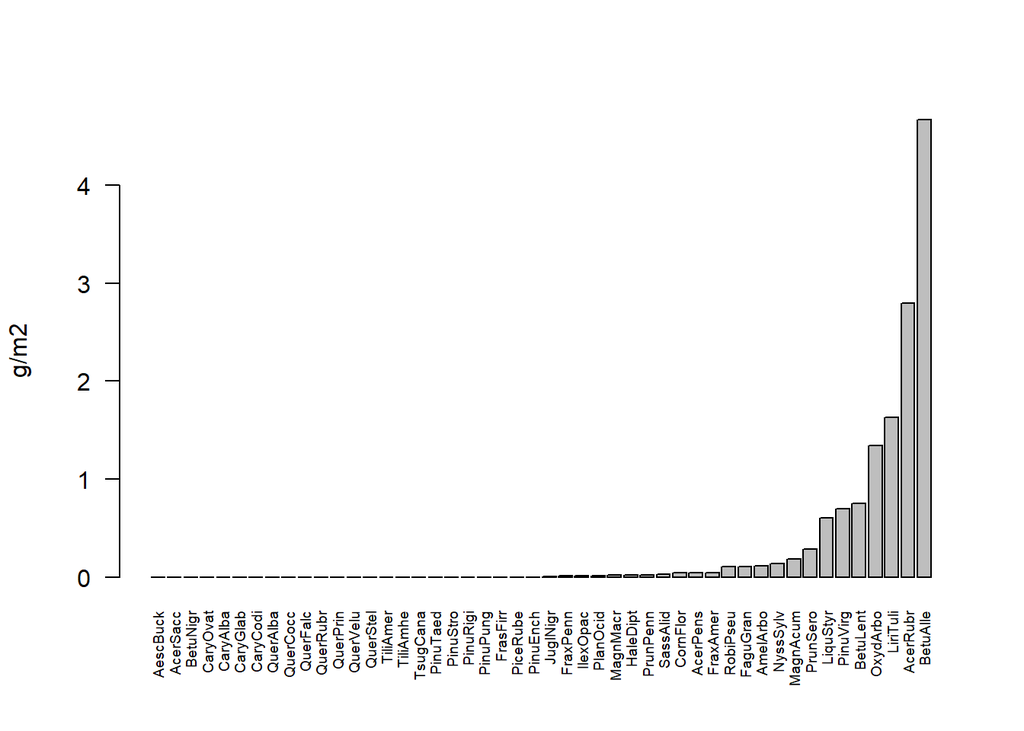

```r
ComThinSums<-(as.data.frame(colSums(ComThin[4:51])))
SP_Nm<-gsub("BiomassHarvestedg_m2__","",colnames(ComThin[4:51]))
ComThinSums$Name<-SP_Nm
colnames(ComThinSums)<-c("Mean","Name")
ComThinSums<-ComThinSums[order(ComThinSums$Mean),]
barplot(ComThinSums$Mean,names=ComThinSums$Name, ylab=c("g/m2"),
        las=2,cex.names=.6)
```

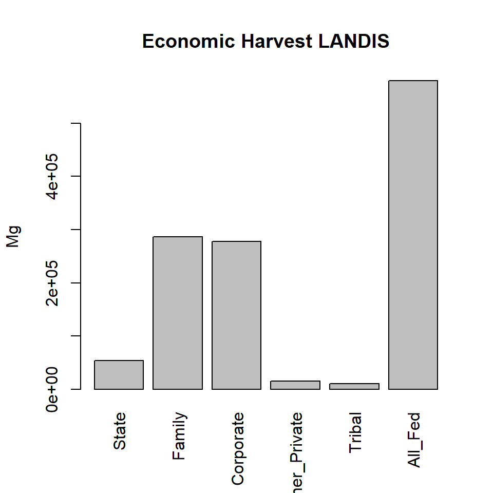

```r
HL_DF<-NULL
for(Management in Managements){
  for(Prescription in Prescriptions){
    Harv<- LS_s[LS_s$Prescription==Prescription,]
    sus<-Harv[Harv$ManagementArea==Management,]

    MergedOneM<-merge(
      sus,
      Ownershipcells,
      by="ManagementArea",
      all.x=T
    )
    MO_Columns<-colnames(MergedOneM)
    Names<-MO_Columns[8:55]
    Names<-gsub("Mg","g_m2_",Names)
    MegaGrams<-MergedOneM[8:55]

    GramMean<-t(as.data.frame(colMeans(MegaGrams)))
    colnames(GramMean)<-Names
    OutRow<-cbind(MergedOneM[1,1:3],GramMean)
    HL_DF<-rbind(OutRow,HL_DF)
  }
}
HL_DF$Total<-rowSums(HL_DF[4:51])
HL_DF<-HL_DF[complete.cases(HL_DF),]

wLUT<-data.frame(ManagementArea=c(1,2,3,4,5,6,7,8),
                Name=c("Federal","State","Local","Family",
                       "Corporate","Other_Private","Tribal","Off"))
HL_DF<-merge(HL_DF,
        LUT,
        by="ManagementArea",
        all.x=T)

ComThin<-HL_DF[HL_DF$Prescription==" CommercialThin",]
EcoHarvest<-HL_DF[HL_DF$Prescription==" EconomicHarvest",]
SL_Ecoharvest<-as.data.frame(cbind(EcoHarvest$Total,EcoHarvest$Name))
colnames(SL_Ecoharvest)<-c("Total","Name")
SL_Ecoharvest<-rbind(SL_Ecoharvest,data.frame(Name="All_Fed",Total=sum(as.numeric(as.character(SL_Ecoharvest$Total[SL_Ecoharvest$Name %in% c("Corporate", "Other_Private","Family")])))))

barplot(as.numeric(as.character(SL_Ecoharvest$Total)),names=SL_Ecoharvest$Name,las=3,ylab="Mg",
        main="Economic Harvest LANDIS")
```